```python
import numpy as np
import cv2 as cv
from matplotlib import pyplot as plt

def disImg(img,BGR2RGB=True):
    if BGR2RGB:
        plt.imshow(cv.cvtColor(img,cv.COLOR_BGR2RGB))
    else:
        plt.imshow(img)
    plt.xticks([]), plt.yticks([])  # 隐藏 x 轴和 y 轴上的刻度值
    plt.show()

def disImg(*img,BGR2RGB=True):
    imgNum=len(img)
    colEx=100+imgNum*10+1
    plt.figure(figsize=(10,10))
    for i in range(imgNum):
        if BGR2RGB:
            plt.subplot(colEx+i),plt.imshow(cv.cvtColor(img[i],cv.COLOR_BGR2RGB))
        else:
            plt.subplot(colEx+i),plt.imshow(img[i])
        plt.xticks([]), plt.yticks([])  # 隐藏 x 轴和 y 轴上的刻度值
    plt.show()

img = cv.imread('Contours.png',cv.IMREAD_GRAYSCALE)
ret,img=cv.threshold(img,150,255,cv.THRESH_BINARY)
```

# 轮廓

轮廓可以简单地解释为连接具有相同颜色或强度的所有连续点（沿边界）的曲线。轮廓是用于形状分析以及对象检测和识别的有用工具。

## 查找与绘制

### 查找轮廓

- 为了获得更高的准确性，请使用二进制图像。因此，在找到轮廓之前，请应用阈值或canny边缘检测。
- 从OpenCV 3.2开始，findContours()不再修改源图像。
- 在OpenCV中，找到轮廓就像从黑色背景中找到白色物体。因此请记住，要找到的对象应该是白色，背景应该是黑色。

#### contours,hierarchy = cv2.findContours(contour,cv2.RETR_TREE,cv2.CHAIN_APPROX_SIMPLE)

```python
contours,hierarchy=cv.findContours(img,cv.RETR_TREE,cv.CHAIN_APPROX_SIMPLE)
print(hierarchy,'\r\n')#轮廓乘次关系
for contour in contours:#打印每个轮廓的shape
    print(contour.shape)
print('\r\n',contours[len(contours)-1])#最后一个轮廓的数据
```

```
[[[ 1 -1 -1 -1]
  [ 3  0  2 -1]
  [-1 -1 -1  1]
  [-1  1  4 -1]
  [-1 -1  5  3]
  [-1 -1 -1  4]]]

(703, 1, 2)
(1827, 1, 2)
(342, 1, 2)
(4, 1, 2)
(8, 1, 2)
(4, 1, 2)

 [[[361 259]]

 [[361 360]]

 [[488 360]]

 [[488 259]]]
```

### 绘制轮廓

- cv2.drawContours(image, contours, contourIdx, color, thickness=None, lineType=None, hierarchy=None, maxLevel=None, offset=None)
  - image 在哪幅图像上绘制轮廓；image为三通道才能显示轮廓
  - contours 轮廓本身，在Python中是一个list
  - contourIdx 指定绘制轮廓list中的哪条轮廓，如果是-1，则绘制其中的所有轮廓。
  - color BGR模式的颜色
  - thickness 表明轮廓线的宽度，如果是-1（cv2.FILLED），则为填充模式。

#### 绘制所有轮廓

[output not shown]

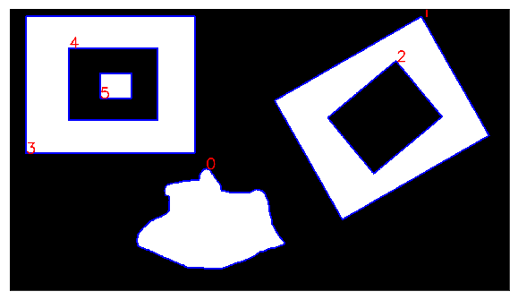

```python
img1=cv.cvtColor(img,cv.COLOR_GRAY2BGR)
cv.drawContours(img1, contours, -1, (255,0,0), 5)#绘制轮廓
print('hierarchy:')
for i in range(len(contours)):
    cv.putText(img1,str(i),tuple(contours[i][1,0]),cv.FONT_HERSHEY_SIMPLEX,2,(0,0,255),4,cv.LINE_AA)
    print('轮廓',i,'- 下一条轮廓：', hierarchy[0,i,0],'  上一条轮廓：', hierarchy[0,i,1],\
         '  父轮廓：',hierarchy[0,i,2],'  子轮廓：',hierarchy[0,i,3])
disImg(img1)
```

#### 绘制某一条轮廓

[figure not shown]

```python
img1=cv.cvtColor(img,cv.COLOR_GRAY2BGR)
#绘制轮廓2
cv.drawContours(img1, contours, 2, (0,255,0), 5)
cv.putText(img1,str(2),tuple(contours[2][1,0]),cv.FONT_HERSHEY_SIMPLEX,2,(0,0,255),4,cv.LINE_AA)
#绘制轮廓4
cnt = contours[4]
cv.drawContours(img1, [cnt], -1, (0,0,255), 5)
cv.putText(img1,str(4),tuple(contours[4][1,0]),cv.FONT_HERSHEY_SIMPLEX,2,(0,0,255),4,cv.LINE_AA)
disImg(img2)
```

## 轮廓特征

轮廓的不同特征包含面积、周长、边界框等

### 面积

- **area=cv.contourArea(contour)**
  - 输入参数 某一条轮廓
  - 输出参数 返回的面积

```python
area=cv.contourArea(contours[0])
area
```

```
145412.0
```

### 周长

- **perimeter = cv.arcLength(contour,True)**
  - 输出参数 长度
  - 输入参数1 某一条轮廓
  - 输入参数2 True计算闭合的轮廓长度，False计算轮廓中所有点组成的曲线长度

```python
perimeter = cv.arcLength(contours[0],True)
perimeter
```

```
1750.704747915268
```

### 轮廓近似

根据我们指定的精度，它可以将轮廓形状近似为顶点数量较少的其他形状。

- **approx = cv.approxPolyDP(contour,epsilon,True)**
  - 输出参数 近似后的轮廓
  - 输入参数1 原轮廓
  - 输入参数2 近似轮廓比原轮廓短了多少，可以使用原轮廓的周长乘以倍数去计算
  - 输入参数3 曲线是否闭合

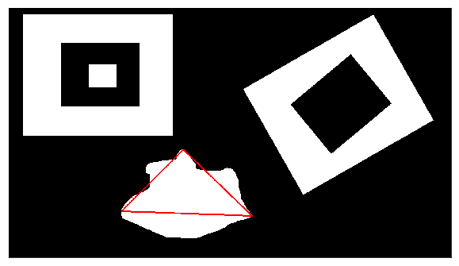

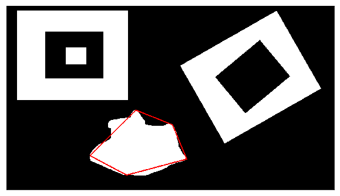

```python
img1=cv.cvtColor(img,cv.COLOR_GRAY2BGR)
img2=cv.cvtColor(img,cv.COLOR_GRAY2BGR)
epsilon1 = 0.1*cv.arcLength(contours[0],True)
approx1 = cv.approxPolyDP(contours[0],epsilon1,True)
epsilon2 = 0.05*cv.arcLength(contours[0],True)
approx2 = cv.approxPolyDP(contours[0],epsilon2,True)
cv.drawContours(img1, [approx1], -1, (0,0,255), 5)
cv.drawContours(img2, [approx2], -1, (0,0,255), 5)
disImg(img1)
disImg(img2)
```

### 轮廓凸包

轮廓上所有最外侧的点连接出的一个封闭曲线

- **hull = cv.convexHull(contour)**

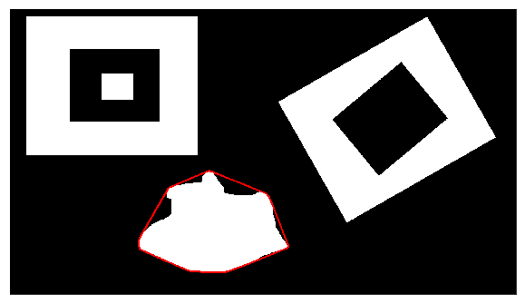

```python
hull = cv.convexHull(contours[0])
img1=cv.cvtColor(img,cv.COLOR_GRAY2BGR)
cv.drawContours(img1, [hull], -1, (0,0,255), 5)
disImg(img1)
```

### 外接矩形

它是一个矩形，不考虑物体的旋转。所以边界矩形的面积不是最小的。它是由函数**cv.boundingRect**()找到的。

(x，y)为矩形的左上角坐标，而(w，h)为矩形的宽度和高度。

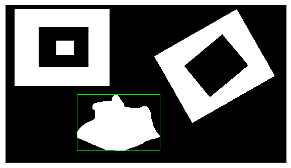

```python
img1=cv.cvtColor(img,cv.COLOR_GRAY2BGR)
x,y,w,h = cv.boundingRect(contours[0])
cv.rectangle(img1,(x,y),(x+w,y+h),(0,255,0),2)
disImg(img1)
```

### 最小外接矩形

边界矩形是用最小面积绘制的，所以它也考虑了旋转。使用的函数是**cv.minAreaRect**()。它返回一个Box2D结构，其中包含以下细节 -(中心(x,y)，(宽度，高度)，旋转角度)。但要画出这个矩形，我们需要矩形的四个角。它由函数**cv.boxPoints**()获得,并将坐标数据类型转为int64

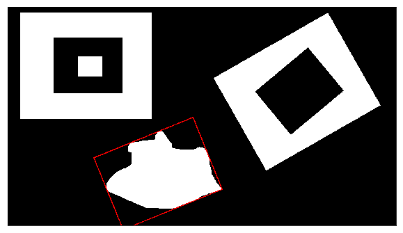

```python
img1=cv.cvtColor(img,cv.COLOR_GRAY2BGR)
rect = cv.minAreaRect(contours[0])
box = cv.boxPoints(rect)
box = np.int64(box)
cv.drawContours(img1,[box],0,(0,0,255),3)
disImg(img1)
```

### 最小闭合圈

接下来，使用函数**cv.minEnclosingCircle**()查找对象的圆周。它是一个以最小面积完全覆盖物体的圆。

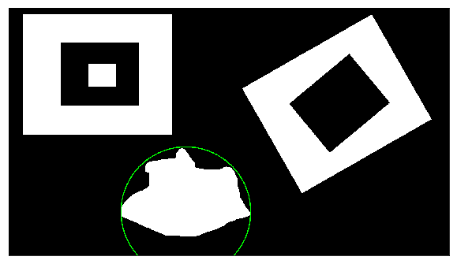

```python
img1=cv.cvtColor(img,cv.COLOR_GRAY2BGR)
(x,y),radius = cv.minEnclosingCircle(contours[0])
center = (int(x),int(y))
radius = int(radius)
cv.circle(img1,center,radius,(0,255,0),4)
disImg(img1)
```

### 拟合一个椭圆

把一个椭圆拟合到一个物体上。它返回内接椭圆的旋转矩形。

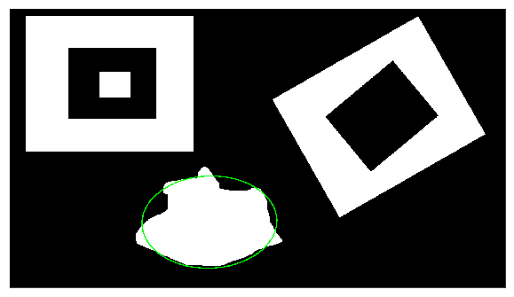

```python
img1=cv.cvtColor(img,cv.COLOR_GRAY2BGR)
ellipse = cv.fitEllipse(contours[0])
cv.ellipse(img1,ellipse,(0,255,0),4)
disImg(img1)
```

### 形状匹配

OpenCV附带一个函数**cv.matchShapes**()，该函数使我们能够比较两个形状或两个轮廓，并返回一个显示相似性的度量。结果越低，匹配越好。

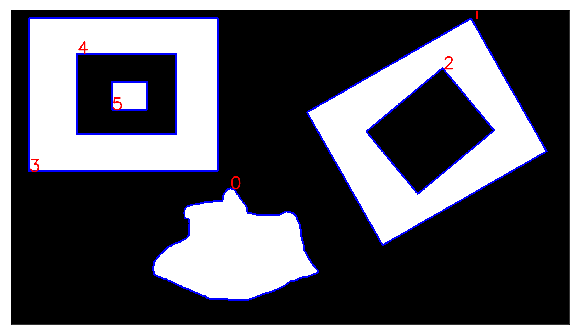

```
0.587679475025444 0.0015075658122312152 0.020175123009308016
```

```python
img1=cv.cvtColor(img,cv.COLOR_GRAY2BGR)
cv.drawContours(img1, contours, -1, (255,0,0), 5)#绘制轮廓
for i in range(len(contours)):
    cv.putText(img1,str(i),tuple(contours[i][1,0]),cv.FONT_HERSHEY_SIMPLEX,2,(0,0,255),4,cv.LINE_AA)
disImg(img1)
ret30 = cv.matchShapes(contours[3],contours[0],2,0.0)
ret31 = cv.matchShapes(contours[3],contours[1],2,0.0)
ret34 = cv.matchShapes(contours[3],contours[4],2,0.0)
print(ret30,ret31,ret34)
```